# trip_data

Saeed Memon

Load in the required libraries.

```r
library(rmarkdown) #Help create this report
library(tidyverse)  #helps wrangle data
library(lubridate)  #helps wrangle date attributes
```

```r
library(ggplot2)  #helps visualize data
library(chron) #help convert time into numeric value
```

```r
apr_2020<-read.csv("202004_tripdata.csv")
may_2020<-read.csv("202004_tripdata.csv")
jun_2020<-read.csv("202006_tripdata.csv")
jul_2020<-read.csv("202007_tripdata.csv")
aug_2020<-read.csv("202008_tripdata.csv")
sep_2020<-read.csv("202009_tripdata.csv")
oct_2020<-read.csv("202010_tripdata.csv")
nov_2020<-read.csv("202011_tripdata.csv")
dec_2020<-read.csv("202012_tripdata.csv")
jan_2021<-read.csv("202101_tripdata.csv")
feb_2021<-read.csv("202102_tripdata.csv")
mar_2021<-read.csv("202103_tripdata.csv")
apr_2021<-read.csv("202104_tripdata.csv")
```

Now temporary store all data in list to parse through them.

```r
month_2021<- list(apr_2020,may_2020,jun_2020,jul_2020,aug_2020,sep_2020,oct_2020,nov_2020,dec_2020,jan_2021,feb_2021,mar_2021,apr_2021)

iterator = 1
while (iterator < 14) {
  (month_2021[[iterator]] <- rename(month_2021[[iterator]]
               ,trip_id = ride_id
               ,bike_id = rideable_type
               ,start_time = started_at
               ,end_time = ended_at
               ,from_station_name = start_station_name
               ,from_station_id = start_station_id
               ,to_station_name = end_station_name
               ,to_station_id = end_station_id
               ,usertype = member_casual))
  iterator = iterator + 1
}
```

Convert ride_id and rideable_type to character so that they can stack correctly

```r
iterator = 1
while (iterator < 14) {
  month_2021[[iterator]] <- mutate(month_2021[[iterator]]
                                              ,trip_id = as.character(trip_id)
                                              ,bike_id = as.character(bike_id)
                                              ,from_station_id = as.character(from_station_id)
                                              ,to_station_id = as.character(to_station_id))

  iterator = iterator + 1
}
```

Now the data is formatted now combine them into one big data frame.

```r
all_trips <- bind_rows(month_2021[[1]]
                       ,month_2021[[2]]
                       ,month_2021[[3]]
                       ,month_2021[[4]]
                       ,month_2021[[5]]
                       ,month_2021[[6]]
                       ,month_2021[[7]]
                       ,month_2021[[8]]
                       ,month_2021[[9]]
                       ,month_2021[[10]]
                       ,month_2021[[11]]
                       ,month_2021[[12]]
                       ,month_2021[[13]])
```

Remove unused columns such as latitude and longitude, and remove n/a values to clean data

```r
all_trips <- all_trips %>%
  select(-c(start_lat, start_lng, end_lat, end_lng))

all_trips <- na.omit(all_trips) #Remove data that has missing information.
```

Data frame inspection

```r
# Inspect the new table that has been created
colnames(all_trips)  #List of column names
nrow(all_trips)  #How many rows are in data frame?
dim(all_trips)  #Dimensions of the data frame?
head(all_trips)  #See the first 6 rows of data frame.  Also tail(qs_raw)
str(all_trips)  #See list of columns and data types (numeric, character, etc)
summary(all_trips)  #Statistical summary of data. Mainly for numerics
```

[output not shown]

Splite columns to create day, month, year into indivdual columns

```r
all_trips$date <- as.Date(all_trips$start_time,format="%m/%d/%Y") #The default format is yyyy-mm-dd
all_trips$month <- format(as.Date(all_trips$date), "%m")
all_trips$day <- format(as.Date(all_trips$date), "%d")
all_trips$year <- format(as.Date(all_trips$date), "%Y")
all_trips$day_of_week <- format(as.Date(all_trips$date), "%A")
```

Convert ride_length from character into numeric for calculation and analysis

```r
print(all_trips$ride_length)
converted_time <- as.numeric(times(all_trips$ride_length))
print(converted_time)
all_trips$ride_length<-60* 24 * converted_time
print(all_trips$ride_length)

all_trips <- na.omit(all_trips) #filter out dates with incorrect format, blank etc.
```

Now start with some basic analysis with mean,min, max and median

```r
mean(all_trips$ride_length) #straight average (total ride length / rides)
median(all_trips$ride_length) #midpoint number in the ascending array of ride lengths
max(all_trips$ride_length) #longest ride
min(all_trips$ride_length) #shortest ride

summary(all_trips$ride_length)
```

[output not shown]

A Clear comparison between members and casuals.

```r
aggregate(all_trips$ride_length ~ all_trips$usertype, FUN = mean)
```

| all_trips$usertype | all_trips$ride_length |
| --- | --- |
| casual | 35.78261 |
| member | 15.31333 |

```r
aggregate(all_trips$ride_length ~ all_trips$usertype, FUN = median)
```

| all_trips$usertype | all_trips$ride_length |
| --- | --- |
| casual | 20.86667 |
| member | 11.31667 |

```r
aggregate(all_trips$ride_length ~ all_trips$usertype, FUN = max)
```

| all_trips$usertype | all_trips$ride_length |
| --- | --- |
| casual | 1439.900 |
| member | 1439.717 |

```r
aggregate(all_trips$ride_length ~ all_trips$usertype, FUN = min)
```

| all_trips$usertype | all_trips$ride_length |
| --- | --- |
| casual | 0 |
| member | 0 |

```r
# reorder day of week.
all_trips$day_of_week <- ordered(all_trips$day_of_week, levels=c("Sunday", "Monday", "Tuesday", "Wednesday", "Thursday", "Friday", "Saturday"))
# average ride time by each day for members vs casual users
aggregate(all_trips$ride_length ~ all_trips$usertype + all_trips$day_of_week, FUN = mean)
```

| all_trips$usertype | all_trips$day_of_week | all_trips$ride_length |
| --- | --- | --- |
| casual | Sunday | 40.08032 |
| member | Sunday | 17.28081 |
| casual | Monday | 35.12002 |
| member | Monday | 14.64095 |
| casual | Tuesday | 33.67318 |
| member | Tuesday | 14.62073 |
| casual | Wednesday | 31.88445 |
| member | Wednesday | 14.39676 |
| casual | Thursday | 32.30084 |
| member | Thursday | 14.49974 |

[output cut: 4 more lines]

now the data analyze ridership data by type and weekday

```r
all_trips %>%
  mutate(weekday = day_of_week) %>%  #creates weekday field using wday()
  group_by(usertype, weekday) %>%  #groups by usertype and weekday
  summarise(number_of_rides = n()                           #calculates the number of rides and average duration
            ,average_duration = mean(ride_length)) %>%      # calculates the average duration
  arrange(usertype, weekday)                                # sorts
```

| usertype | weekday | number_of_rides | average_duration |
| --- | --- | --- | --- |
| casual | Sunday | 270667 | 40.08032 |
| casual | Monday | 152447 | 35.12002 |
| casual | Tuesday | 156424 | 33.67318 |
| casual | Wednesday | 155415 | 31.88445 |
| casual | Thursday | 165554 | 32.30084 |
| casual | Friday | 211304 | 33.77991 |
| casual | Saturday | 326218 | 38.45922 |
| member | Sunday | 278613 | 17.28081 |
| member | Monday | 280328 | 14.64095 |
| member | Tuesday | 304482 | 14.62073 |

[output cut: 4 more lines]

Here is a plot of number of rides per user type.

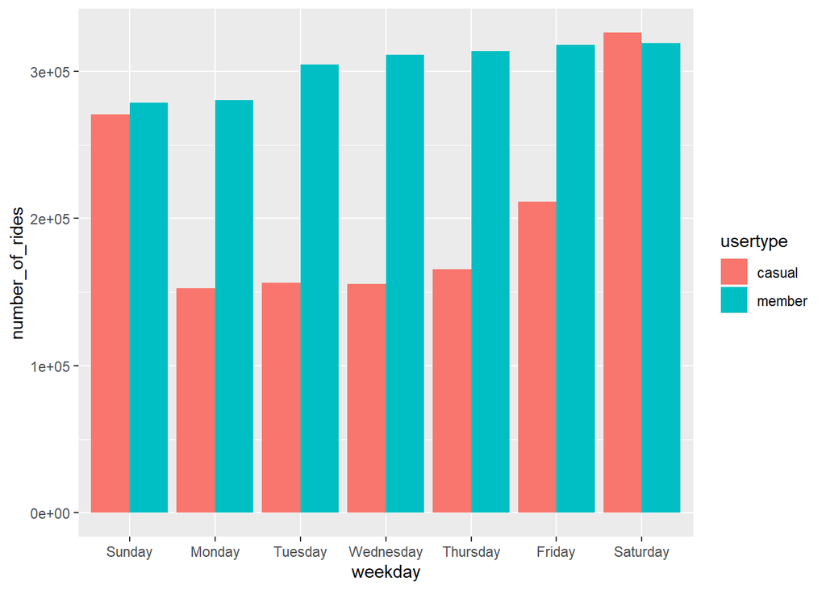

```r
# visualize the number of rides by rider type
all_trips %>%
  mutate(weekday = day_of_week) %>%
  group_by(usertype, weekday) %>%
  summarise(number_of_rides = n()
            ,average_duration = mean(ride_length)) %>%
  arrange(usertype, weekday)  %>%
  ggplot(aes(x = weekday, y = number_of_rides, fill = usertype)) +
    geom_col(position = "dodge")
```

This graph represents average ride duration of members and casuals in a weekly basis.

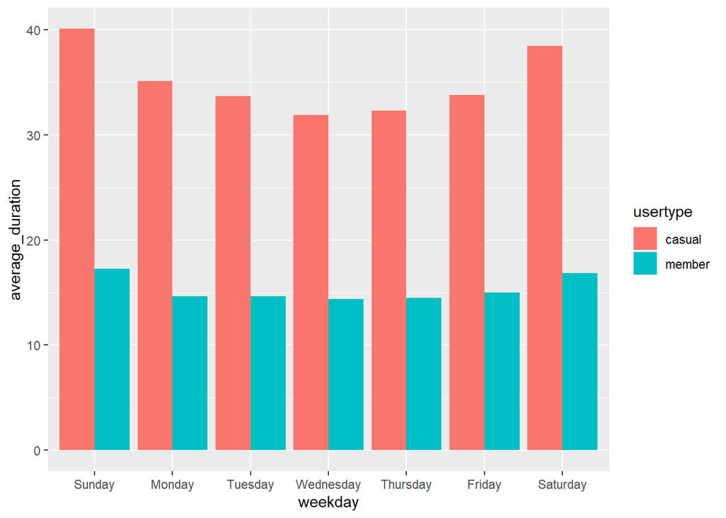

```r
all_trips %>%
  mutate(weekday = day_of_week) %>%
  group_by(usertype, weekday) %>%
  summarise(number_of_rides = n()
            ,average_duration = mean(ride_length)) %>%
  arrange(usertype, weekday)  %>%
  ggplot(aes(x = weekday, y = average_duration, fill = usertype)) +
  geom_col(position = "dodge")
```

Now, with data analysis and visualization I recommend:

1. Create plans to gear towards longer rider duration to attract more casuals cyclist to become a member.
2. Based on the First chart we can visually see there is significant more rides coming from causal cyclist during the weekend, this could show that there is a big jump in cyclist during their free time, maybe with familys and friend, The company can focus plan and market toward the weekend cyclist to attract more members.